# Threat and Demography Scores, Analysis 2

Jacob Malcom, Whitney Webber, Ya-Wei Li

2016-06-14

## Applying the key to a (large-ish) set of species

### Florida species in general

```r
summary_all <- stat.desc(FL_all)
summary_all <- t(summary_all[c(1,3,4,5,8:11,13), c(-4,-1)])
summary_all <- data.frame(summary_all)
names(summary_all) <- c("n", "N/A", "min", "max", "median", "mean", "s.e.",
                        "95% CI", "s.d.")
summary_all
```

```
##             n N/A min max median       mean       s.e.    95% CI      s.d.
## Demography 50   4  -1   1     -1 -0.5500000 0.09923174 0.1994137 0.7016744
## Threat     54   0  -1   1     -1 -0.6296296 0.07140546 0.1432212 0.5247208
```

On average, the threats have worsened and demographic status has declined for these 54 Florida species. Most of these species are not recommended for a status change, but we can compare the tallies of recommendation by score:

```
## Threat scores:
```

```
##   Downlist        N/A  No change   Revision
##  0.3333333 -1.0000000 -0.5675676 -1.0000000
```

```
##
##        Downlist N/A No change Revision
##   -1          0  12        17        2
##   -0.5        1   0        11        0
##   0           0   0         6        0
##   0.5         1   0         3        0
##   1           1   0         0        0
```

```
## Demography scores:
```

```
##  Downlist       N/A No change  Revision
##       1.0      -1.0      -0.5      -1.0
```

```
##
##        Downlist N/A No change Revision
##   -1          0  12        18        2
##   -0.5        0   0         5        0
##   0           0   0         4        0
##   0.5         0   0         4        0
##   1           3   0         2        0
```

Although ‘threats’ and ‘demography’ are fundamentally different, they are related (threat changes cause demographic changes…and in some cases, demographic changes can introduce or make relevant new threats):

```
## Correlation between threat and demography scores:
```

```
##
##  Pearson's product-moment correlation
##
## data:  FL_all$Threat and FL_all$Demography
## t = 7.1912, df = 48, p-value = 3.747e-09
## alternative hypothesis: true correlation is not equal to 0
## 95 percent confidence interval:
##  0.5525676 0.8317692
## sample estimates:
##       cor
## 0.7201517
```

We can also view the threat and demographic scores as a scatterplot:

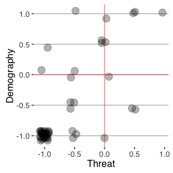

These results are discussed in greater detail in the paper.

### Repeatability of scoring

We would like to know the extent to which different people read the same information and arrive at different scores. Four additional people scored a random selection of ten of the Florida species, using the same 5-yr reviews and/or Federal Register documents. First, the summaries of the threat and demography scores:

```
##             n N/A min max median       mean      s.e.    95% CI      s.d.
## Threat     49   1  -1   1   -0.5 -0.2653061 0.1032034 0.2075044 0.7224239
## Demography 42   8  -1   1    0.0 -0.0952381 0.1243311 0.2510917 0.8057574
```

Across five scorers, these then species have negative threat scores and demographic scores are trending negative. We now want to test for observer effects. First, for threat scores:

```r
th_m1 <- lm(Threat ~ Person + Species, data = multi)
anova(th_m1)
```

```
## Analysis of Variance Table
##
## Response: Threat
##           Df  Sum Sq Mean Sq F value    Pr(>F)
## Person     4  0.5205 0.13012  0.5360    0.7102
## Species    9 16.0340 1.78156  7.3388 6.409e-06 ***
## Residuals 35  8.4965 0.24276
## ---
## Signif. codes:  0 '***' 0.001 '**' 0.01 '*' 0.05 '.' 0.1 ' ' 1
```

```r
summary(th_m1)
```

```
##
## Call:
## lm(formula = Threat ~ Person + Species, data = multi)
##
## Residuals:
##     Min      1Q  Median      3Q     Max
## -1.0264 -0.2444 -0.0625  0.1736  0.9236
##
## Coefficients:
##                                                                              Estimate
## (Intercept)                                                                  -1.05556
## PersonJM                                                                      0.13194
## PersonKC                                                                      0.18194
## PersonRC                                                                     -0.11806
## PersonYL                                                                      0.08194
## SpeciesDarter, Okaloosa Entire (Etheostoma okaloosae)                         1.80000
## SpeciesManatee, West Indian Entire (Trichechus manatus)                       1.20000
## SpeciesMouse, Perdido Key beach Entire (Peromyscus polionotus trissyllepsis)  1.00000
## SpeciesPigtoe, fuzzy  (Pleurobema strodeanum)                                 0.30000
## SpeciesPigtoe, oval  (Pleurobema pyriforme)                                   0.23611
## SpeciesSnake, Atlantic salt marsh Entire (Nerodia clarkii taeniata)           0.90000
## SpeciesSparrow, Cape Sable seaside Entire (Ammodramus maritimus mirabilis)    0.40000
## SpeciesStork, wood AL, FL, GA, MS, NC, SC (Mycteria americana)                1.30000
## SpeciesWoodrat, Key Largo Entire (Neotoma floridana smalli)                   0.10000
##                                                                              Std. Error
## (Intercept)                                                                     0.26482
## PersonJM                                                                        0.22787
## PersonKC                                                                        0.22787
## PersonRC                                                                        0.22787
## PersonYL                                                                        0.22787
## SpeciesDarter, Okaloosa Entire (Etheostoma okaloosae)                           0.31161
## SpeciesManatee, West Indian Entire (Trichechus manatus)                         0.31161
## SpeciesMouse, Perdido Key beach Entire (Peromyscus polionotus trissyllepsis)    0.31161
## SpeciesPigtoe, fuzzy  (Pleurobema strodeanum)                                   0.31161
## SpeciesPigtoe, oval  (Pleurobema pyriforme)                                     0.33255
## SpeciesSnake, Atlantic salt marsh Entire (Nerodia clarkii taeniata)             0.31161
## SpeciesSparrow, Cape Sable seaside Entire (Ammodramus maritimus mirabilis)      0.31161
## SpeciesStork, wood AL, FL, GA, MS, NC, SC (Mycteria americana)                  0.31161
## SpeciesWoodrat, Key Largo Entire (Neotoma floridana smalli)                     0.31161
##                                                                              t value
```

[output cut: 36 more lines]

```
## SpeciesManatee, West Indian Entire (Trichechus manatus)                      ***
## SpeciesMouse, Perdido Key beach Entire (Peromyscus polionotus trissyllepsis) **
## SpeciesPigtoe, fuzzy  (Pleurobema strodeanum)
## SpeciesPigtoe, oval  (Pleurobema pyriforme)
## SpeciesSnake, Atlantic salt marsh Entire (Nerodia clarkii taeniata)          **
## SpeciesSparrow, Cape Sable seaside Entire (Ammodramus maritimus mirabilis)
## SpeciesStork, wood AL, FL, GA, MS, NC, SC (Mycteria americana)               ***
## SpeciesWoodrat, Key Largo Entire (Neotoma floridana smalli)
## ---
## Signif. codes:  0 '***' 0.001 '**' 0.01 '*' 0.05 '.' 0.1 ' ' 1
##
## Residual standard error: 0.4927 on 35 degrees of freedom
##   (1 observation deleted due to missingness)
## Multiple R-squared:  0.6608, Adjusted R-squared:  0.5349
## F-statistic: 5.246 on 13 and 35 DF,  p-value: 4.359e-05
```

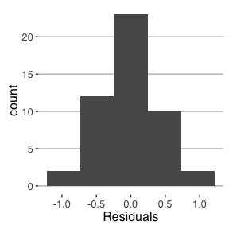

```r
qplot(resid(th_m1),
      geom = "histogram",
      xlab = "Residuals",
      bins = 5) + theme_hc()
```

```r
ICC_thr <- ICCest(x = Species, y = Threat, data = multi)
```

```
## NAs removed from rows:
##  21
```

```r
ICC_thr
```

```
## $ICC
## [1] 0.5762861
##
## $LowerCI
## [1] 0.3013832
##
## $UpperCI
## [1] 0.840915
##
## $N
## [1] 10
##
## $k
## [1] 4.897959
##
## $varw
## [1] 0.2320513
##
## $vara
## [1] 0.315609
```

The threat scores are not strongly affected by observer (n.s. `person` term and small mean square), and the intra-species correlation is decent. Now for demography scores:

```r
dem_m1 <- lm(Demography ~ Person + Species, data = multi)
anova(dem_m1)
```

```
## Analysis of Variance Table
##
## Response: Demography
##           Df  Sum Sq Mean Sq F value    Pr(>F)
## Person     4  2.9055 0.72636  4.2597  0.008111 **
## Species    9 18.9390 2.10434 12.3407 1.285e-07 ***
## Residuals 28  4.7746 0.17052
## ---
## Signif. codes:  0 '***' 0.001 '**' 0.01 '*' 0.05 '.' 0.1 ' ' 1
```

```r
summary(dem_m1)
```

```
##
## Call:
## lm(formula = Demography ~ Person + Species, data = multi)
##
## Residuals:
##      Min       1Q   Median       3Q      Max
## -0.61071 -0.20759 -0.07024  0.17805  0.81637
##
## Coefficients:
##                                                                              Estimate
## (Intercept)                                                                  -0.70982
## PersonJM                                                                     -0.37351
## PersonKC                                                                      0.24107
## PersonRC                                                                     -0.20685
## PersonYL                                                                      0.05357
## SpeciesDarter, Okaloosa Entire (Etheostoma okaloosae)                         1.26696
## SpeciesManatee, West Indian Entire (Trichechus manatus)                       1.16696
## SpeciesMouse, Perdido Key beach Entire (Peromyscus polionotus trissyllepsis)  1.36696
## SpeciesPigtoe, fuzzy  (Pleurobema strodeanum)                                 0.16696
## SpeciesPigtoe, oval  (Pleurobema pyriforme)                                   0.28125
## SpeciesSnake, Atlantic salt marsh Entire (Nerodia clarkii taeniata)           0.58333
## SpeciesSparrow, Cape Sable seaside Entire (Ammodramus maritimus mirabilis)    0.06696
## SpeciesStork, wood AL, FL, GA, MS, NC, SC (Mycteria americana)                1.66696
## SpeciesWoodrat, Key Largo Entire (Neotoma floridana smalli)                  -0.23304
##                                                                              Std. Error
## (Intercept)                                                                     0.34791
## PersonJM                                                                        0.21273
## PersonKC                                                                        0.21549
## PersonRC                                                                        0.21273
## PersonYL                                                                        0.21549
## SpeciesDarter, Okaloosa Entire (Etheostoma okaloosae)                           0.35484
## SpeciesManatee, West Indian Entire (Trichechus manatus)                         0.35484
## SpeciesMouse, Perdido Key beach Entire (Peromyscus polionotus trissyllepsis)    0.35484
## SpeciesPigtoe, fuzzy  (Pleurobema strodeanum)                                   0.35484
## SpeciesPigtoe, oval  (Pleurobema pyriforme)                                     0.36499
## SpeciesSnake, Atlantic salt marsh Entire (Nerodia clarkii taeniata)             0.51503
## SpeciesSparrow, Cape Sable seaside Entire (Ammodramus maritimus mirabilis)      0.35484
## SpeciesStork, wood AL, FL, GA, MS, NC, SC (Mycteria americana)                  0.35484
## SpeciesWoodrat, Key Largo Entire (Neotoma floridana smalli)                     0.35484
##                                                                              t value
```

[output cut: 36 more lines]

```
## SpeciesManatee, West Indian Entire (Trichechus manatus)                      **
## SpeciesMouse, Perdido Key beach Entire (Peromyscus polionotus trissyllepsis) ***
## SpeciesPigtoe, fuzzy  (Pleurobema strodeanum)
## SpeciesPigtoe, oval  (Pleurobema pyriforme)
## SpeciesSnake, Atlantic salt marsh Entire (Nerodia clarkii taeniata)
## SpeciesSparrow, Cape Sable seaside Entire (Ammodramus maritimus mirabilis)
## SpeciesStork, wood AL, FL, GA, MS, NC, SC (Mycteria americana)               ***
## SpeciesWoodrat, Key Largo Entire (Neotoma floridana smalli)
## ---
## Signif. codes:  0 '***' 0.001 '**' 0.01 '*' 0.05 '.' 0.1 ' ' 1
##
## Residual standard error: 0.4129 on 28 degrees of freedom
##   (8 observations deleted due to missingness)
## Multiple R-squared:  0.8206, Adjusted R-squared:  0.7374
## F-statistic: 9.854 on 13 and 28 DF,  p-value: 2.812e-07
```

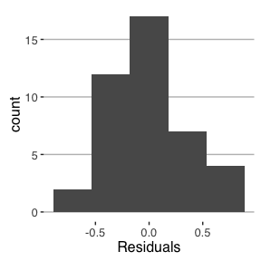

```r
qplot(resid(dem_m1),
      geom = "histogram",
      xlab = "Residuals",
      bins = 5) + theme_hc()
```

```r
ICC_thr <- ICCest(x = Species, y = Demography, data = multi)
```

```
## NAs removed from rows:
##  6 16 19 21 26 29 36 39
```

```r
ICC_thr
```

```
## $ICC
## [1] 0.7022751
##
## $LowerCI
## [1] 0.4385541
##
## $UpperCI
## [1] 0.899801
##
## $N
## [1] 10
##
## $k
## [1] 4.148148
##
## $varw
## [1] 0.20625
##
## $vara
## [1] 0.4865035
```

The `person` term is statistically significant for demography scores, but the within-species correlations are stronger than for threat scores.

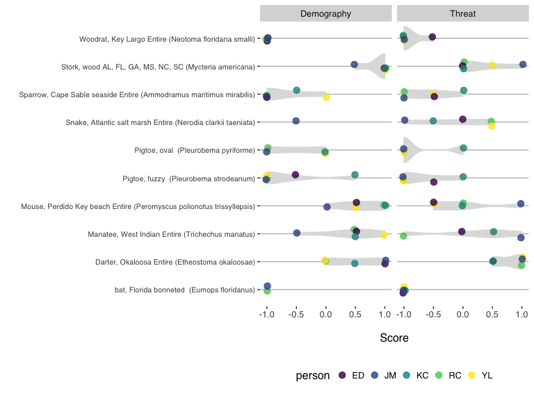